# Przygotowanie komputera: R, RStudio, pakiety

XXXII OGÓLNOPOLSKA SZKOŁA ZINTEGROWANEGO MONITORINGU  
ŚRODOWISKA PRZYRODNICZEGO  
Wprowadzenie do pracy w środowisku R (23 września 2026, 12.30–14.00)

Autor

Anna Dmowska, Robert Kruszyk, Mikołaj Majewski, Krzysztof Klincewicz, Natalia Wróbel

*Materiały zostały opracowane z wykorzystaniem Claude*

**Potrzebne materiały znajdują się w folderze `INSTRUKCJA_INSTALACJI`** (`instaluj_pakiety.R`, `test.qmd`).

# Krok 1. Zainstaluj R

1. Wejdź na **cran.r-project.org**, kliknij *Download R for Windows* (albo *for macOS*)
2. Kliknij *base*, a potem duży link *Download R x.x.x for Windows*
3. Uruchom pobrany plik i przeklikaj instalator, **nic nie zmieniając**

# Krok 2. Zainstaluj RStudio

Kolejność ma znaczenie: RStudio szuka R przy pierwszym uruchomieniu i musi go już zastać na dysku.

1. Wejdź na **docs.posit.co/ide/user** i w sekcji *Direct Downloads (Open Source)* pobierz **RStudio Desktop** (nie *Server*, nie *Pro*)
2. Przeklikaj instalator, nic nie zmieniając
3. Uruchom RStudio. Przy pierwszym uruchomieniu (Windows) pojawi się okno *Choose R Installation*: zaznacz **trzecią opcję**, wskaż wersję z Kroku 1 i kliknij *OK*

[figure not shown]

# Krok 3. Zainstaluj pakiety

Pakiet to dodatek do R. Potrzebnych jest 16 pakietów; z zależnościami ponad sto. Instaluje je jeden skrypt.

1. W RStudio wybierz **File → Open File…** i wskaż `instaluj_pakiety.R`
2. Kliknij **Source** w prawym górnym rogu okna z kodem (skrót `Ctrl+Shift+S`)

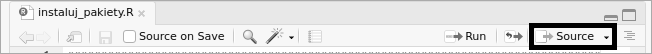

3. Czekaj **od kilkunastu do trzydziestu minut**. Nie zamykaj RStudio i nie klikaj *Source* drugi raz
4. Na końcu w konsoli pojawi się `Pakiety: komplet (16 pakietów).` oraz `>>> Gotowe.` Jeśli któraś linia mówi `[BRAK]`, kliknij *Source* jeszcze raz

> **Trzy rzeczy, które mylą najczęściej.** *Source*, nie *Run* – *Run* wykonuje tylko jedną linię. Żółty pasek *Package quarto required but is not installed* zignoruj, **nie klikaj** *Install*. Czerwony tekst w konsoli to nie błąd – liczy się podsumowanie na końcu.

# Krok 4. Sprawdź, czy wszystko działa

1. Wybierz **File → Open File…** i wskaż `test.qmd`
2. Kliknij **Render** nad oknem z tekstem (skrót `Ctrl+Shift+K`)

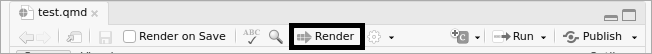

3. Po kilkunastu sekundach obok pliku powstanie `test.docx` i otworzy się w Wordzie

**Jeśli dokument się otworzył – komputer jest gotowy.** Znaczy to, że działa R, działają pakiety i działa Quarto.

# Jak pracuje się z dokumentem Quarto

Plik `.qmd` łączy **tekst** i **kod R**. Kliknięcie **Render** uruchamia kod, zbiera wyniki – liczby, tabele, wykresy – i wstawia je w tekst. Powstaje gotowy dokument Worda, bez przeklejania czegokolwiek ręcznie.

- otwierasz plik `.qmd` przez **File → Open File…**, klikasz **Render** (`Ctrl+Shift+K`)
- gotowy dokument powstaje w tym samym folderze co plik `.qmd`
- **zamknij poprzedni plik `.docx` przed ponownym renderowaniem** – otwarty dokument blokuje zapis i render zakończy się błędem
- od tej pory otwierasz wyłącznie RStudio; programu R nigdy nie uruchamiasz bezpośrednio

# Warsztat: folder `WPROWADZENIE`

Folder z materiałami do zajęć zawiera cztery pliki:

| Plik | Do czego służy |
| --- | --- |
| `1_wprowadzenie.Rproj` | plik projektu – **otwierasz go jako pierwszy** |
| `1_wprowadzenie.qmd` | dokument Quarto, z którego powstaje raport |
| `.Renviron.example` | szablon danych dostępowych – **uzupełniasz go na zajęciach** |
| `dane_warsztat.RData` | dane zapasowe, na wypadek problemów z bazą |

## Krok 1. Przygotuj plik `.Renviron`

Dane do połączenia z bazą R czyta z pliku `.Renviron`. W folderze leży na razie sam szablon `.Renviron.example` – z wpisanym adresem serwera, portem i nazwą bazy. **Nazwę użytkownika i hasło podajemy na początku zajęć.**

1. **Skopiuj** `.Renviron.example` i zmień nazwę kopii na `.Renviron` – usuń końcówkę `.example`. Jeśli plik nie jest widoczny, włącz *Widok → Pokaż → Ukryte elementy*
2. Otwórz go w Notatniku i wpisz w cudzysłowie otrzymane dane – `ZMSP_DB_USER` oraz `ZMSP_DB_PASSWORD`. Pozostałych trzech linii nie zmieniasz
3. Zapisz plik

Robisz to **przed** uruchomieniem RStudio – R czyta `.Renviron` wyłącznie przy starcie sesji. Gotowego pliku **nie wysyłaj nikomu** – zawiera hasło.

## Krok 2. Otwórz `1_wprowadzenie.Rproj`

Kliknij ten plik dwukrotnie. Uruchomi się RStudio z otwartym **projektem**.

Projekt ustawia **katalog roboczy** na folder warsztatu. To nie jest formalność: dzięki temu R wie, gdzie szukać pozostałych plików – odczytuje `.Renviron` z danymi do bazy i znajduje `dane_warsztat.RData`. Otwarcie samego pliku `.qmd`, z pominięciem projektu, kończy się zwykle błędem połączenia z bazą.

Nazwa otwartego projektu widoczna jest w prawym górnym rogu okna RStudio.

## Krok 3. Otwórz `1_wprowadzenie.qmd`

Dwa sposoby, oba dają ten sam efekt:

- z menu **File → Open File…** i wskaż plik, albo
- w prawym dolnym oknie RStudio przejdź do zakładki **Files** i kliknij nazwę pliku

Treść dokumentu pojawi się w lewej górnej części okna.

## Krok 4. Wyrenderuj dokument

Kliknij **Render** nad oknem z tekstem (skrót `Ctrl+Shift+K`). Dokument łączy się z bazą, pobiera dane i buduje raport – potrwa to kilkanaście sekund.

## Co powstanie

W folderze warsztatu pojawi się plik **`1_wprowadzenie.docx`** i otworzy się w Wordzie. Zawiera wstęp o pracy z Quarto oraz przykładowy raport dla Stacji Bazowej: tabelę z wartościami miesięcznymi i pięć rycin, każdą od nowej strony.

W trakcie zajęć zmienisz w dokumencie **dwie linijki** – kod stacji i rok – i wykonasz render ponownie, otrzymując raport dla własnej stacji.

*Pełna wersja instrukcji, razem z opisem najczęstszych problemów, znajduje się w pliku `INSTRUKCJA_INSTALACJI.pdf`.*